# imports and config

# 💡 Chain of Thought

A series of intermediate reasoning steps.

[figure not shown]

> Credit: https://arxiv.org/abs/2201.11903

```python
response = chat(
    model='llama3.2',
    messages=[
        {
            'role': 'user',
            'content': 'How many r are there in kookaburra? Go through each letter and check if it is r or not.' + context,
        },
    ]
)
print("---")
print(response.message.content)
```

```
---
Let's go through the word "kookaburra" to count the number of R's:

1. K - No R
2. O - No R
3. O - No R
4. K - No R
5. A - No R
6. B - No R
7. U - No R
8. R - Yes!
9. R - Yes!

There are 2 R's in the word "kookaburra".
```

# 🧑‍💻 Reasoning LLMs

[figure not shown]

> Credit: https://newsletter.maartengrootendorst.com/p/a-visual-guide-to-reasoning-llms

```python
# we dont need CoT anymore, the LLMs can reason and show you their latent thoughts!
response = chat(
    model='deepseek-r1:8b',
    messages=[
        {
            'role': 'user',
            'content': 'What is 1 + 1?',
        },
    ]
)
print("---")
print("Thinking:", response.message.model_dump().get('thinking', 'No thinking available'))
print("===")
print("Response:", response.message.content)
```

```
---
Thinking: First, the user asked: "What is 1 + 1?" This is a very basic arithmetic question. I know that 1 + 1 equals 2. It's one of the simplest math facts.

I should respond clearly and directly. Since this is an AI conversation, I can be helpful and engaging. Maybe I can add a bit of humor or a light-hearted comment to make it more interesting, but I need to keep it simple.

Possible responses:

- Straightforward: "1 + 1 equals 2."

- With explanation: "Adding one to one gives you two."

- Humorous: "Well, if 1 + 1 was anything else, what would it be? But in standard arithmetic, it's 2."

But I should avoid being too complicated for such a simple question. The user might be testing me or just starting a conversation.

Also, consider the context. This could be a trick question or something in a different base, but the user didn't specify, so I should assume base 10.

In binary, 1 + 1 is 10, but that might be overcomplicating it. The question doesn't indicate any special context, so I'll go with the standard decimal answer.

Finally, structure the response: Start with the answer, then perhaps a brief explanation or acknowledgment.

Response: "1 + 1 equals 2. That's a basic math fact!"

Or: "The sum of 1 and 1 is 2."

I think that's sufficient.

===
Response: 1 + 1 equals 2. That's a fundamental concept in arithmetic! If you have any more questions, feel free to ask. 😊
```

# 😔 Limitations of (Isolated) LLMs

### 😵‍💫 Hallucination: Generation of incorrect information with high confidence

### 🤨 Knowledge cutoff: Limited to training data timeframe

### 🥸 Lack of attribution: No direct source citations

### 🔒 Data privacy: Limited to public training data, no access to proprietary information

### ↔️ Limited context length: Constraints due to attention mechanism

# 💡 RAG (Retrieval Augmented Generation)

[figure not shown]

> Credit: https://aws.amazon.com/what-is/retrieval-augmented-generation

```python
from agno.agent import Agent
from agno.knowledge.embedder.sentence_transformer import SentenceTransformerEmbedder
from agno.knowledge.knowledge import Knowledge
from agno.models.ollama import Ollama
from agno.vectordb.lancedb import LanceDb, SearchType

# Create knowledge base with hybrid search
knowledge = Knowledge(
    vector_db=LanceDb(
        uri="./lancedb",
        table_name="nvidia_8k_document",
        search_type=SearchType.keyword,  # Semantic + keyword search
        embedder=SentenceTransformerEmbedder()
    ),
)

# knowledge.add_content(
#     name="nvidia_8k_document",
#     path="./nvidia-8k.txt"
# )

# Create agent with knowledge and session persistence
agno_assist = Agent(
    name="Agno Assist",
    model=Ollama(id="llama3.1:8b"),
    knowledge=knowledge,
    markdown=True,
)

response = agno_assist.run("Explain Project GR00T AI? Look into your knowledge base for the answer. Answer in concise manner.")
print(response.content)
```

```
INFO Found 3 documents
```

[output not shown]

# 🛠️ Tool Use

```python
from agno.agent import Agent
from agno.models.ollama import Ollama
from agno.tools.duckduckgo import DuckDuckGoTools

# Create agent with DuckDuckGo search tool
agno_assist = Agent(
    name="Agno Assist",
    model=Ollama(id="llama3.1:8b"),
    tools=[DuckDuckGoTools()],
    markdown=True,
)

response = agno_assist.run("Explain Project GR00T AI? Search the web for the answer. Answer in concise manner.")
print(response.content)
```

```
**Project GR00T AI**

Project GR00T AI, also known as NVIDIA Isaac GR00T, is a research initiative and development platform by NVIDIA. It aims to develop general-purpose robot foundation models and data pipelines for accelerating humanoid robotics research and development.

**Key Features:**

* Generalist robot foundation models
* Data pipelines for accelerating humanoid robotics research and development

**Purpose:** To advance the field of humanoid robotics and enable faster development of robots with human-like capabilities.
```

# 🧠 Memory

```python
from agno.agent import Agent
from agno.models.ollama import Ollama
from agno.tools.mem0 import Mem0Tools

user_id = "agno"

# Create agent with Mem0Tools for memory management
agent = Agent(
    model=Ollama(id="llama3.1:8b"),
    tools=[Mem0Tools(user_id=user_id)],
    instructions=[
        "You are my calendar assistant.",
        "You have to keep track of my schedule.",
        "Store important information about my events and preferences.",
        "When I ask you to check my schedule for a specific date and time, search your memory for any events scheduled for that date and time.",
        "If I have an event scheduled, you should tell me that I have an event scheduled for that date and time.",
        "If I don't have an event scheduled, you should tell me that my schedule is free for that date and time.",
    ],
    markdown=True,
)

# First, let's add some memories
agent.print_response("Remember that my name is Puneet and I live in Chandigarh.", stream=True)
agent.print_response("Remember that I'm going to a concert on April 8 from 6 - 9 PM.", stream=True)

# Now check if schedule is free
agent.print_response("I want to go to the movies on April 8 around 6:30 PM, is my schedule free?", stream=True)

# https://app.mem0.ai/dashboard/memories
```

```
Output()
```

```
Output()
```

```
Output()
```

[output not shown]

# So many cool tools, but no standard way to use them!

# 🌐 Model Context Protocol

[figure not shown]

> Credit: https://modelcontextprotocol.io/

[figure not shown]

> Credit: https://www.atlassian.com/blog/announcements/remote-mcp-server

[figure not shown]

> Credit: https://www.linkedin.com/posts/ai-agents-and-the-model-context-protocol-ugcPost-7330644107356217345-Czgu/

```python
from textwrap import dedent
import asyncio
import nest_asyncio
from agno.agent import Agent
from agno.models.ollama import Ollama
from agno.tools.mcp import MCPTools

# Allow nested event loops (needed for Jupyter notebooks)
nest_asyncio.apply()


async def run_agent(message: str) -> None:
    """Run the filesystem agent with the given message."""

    file_path = "/home/abrol/agents/"

    # Initialize and connect to the MCP server to access the filesystem
    print("calling", f"npx -y @modelcontextprotocol/server-filesystem {file_path}")
    mcp_tools = MCPTools(command=f"npx -y @modelcontextprotocol/server-filesystem {file_path}")
    await mcp_tools.connect()

    try:
        agent = Agent(
            model=Ollama(id="llama3.1:8b"),
            tools=[mcp_tools],
            instructions=dedent("""\
                You are a filesystem assistant. Help users explore files and directories.

                - Navigate the filesystem to answer questions
                - Use the read_file tool to read the contents of files\
            """),
            markdown=True,
        )

        # Run the agent
        await agent.aprint_response(message, stream=True)
    finally:
        # Always close the connection when done
        await mcp_tools.close()


# Example usage - run directly with await in Jupyter
# Basic example - exploring project license
await run_agent("What is the license for /home/abrol/agents/? Read the LICENSE.txt file to find out.")
```

```
calling npx -y @modelcontextprotocol/server-filesystem /home/abrol/agents/
```

```
Output()
```

# 🧑‍🤝‍🧑 Multi-Agent Systems

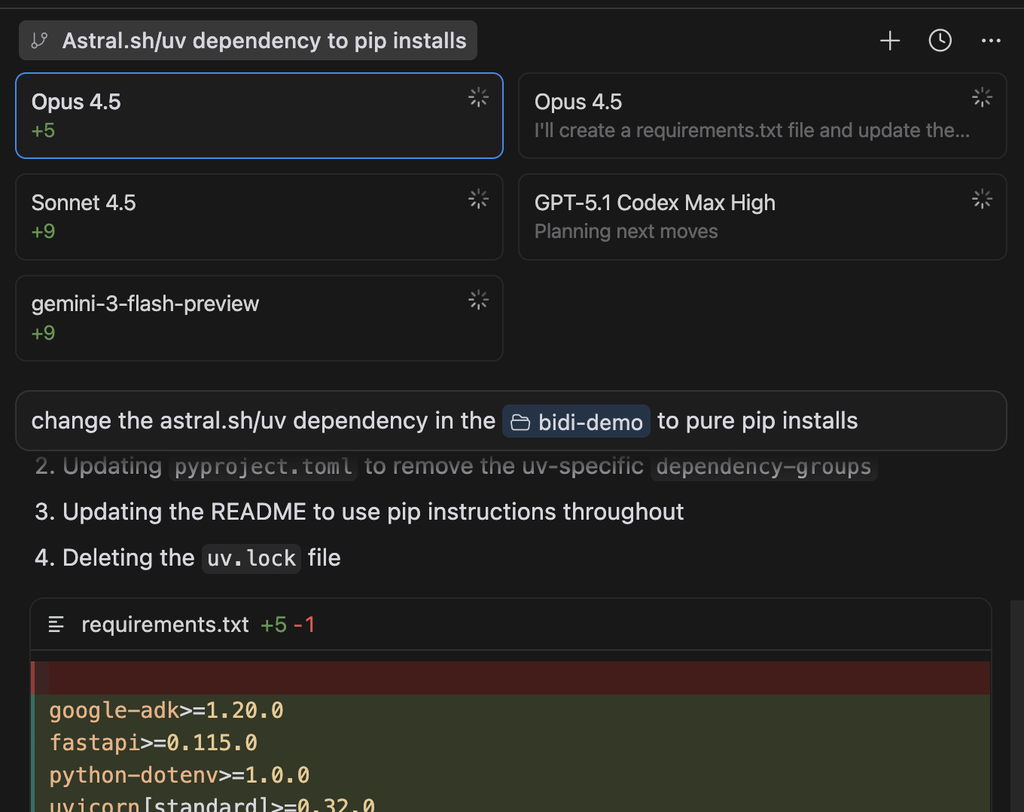

> Credit: Screenshot of CursorAI Code Editor

# 👨‍🎨 Agnets with personality

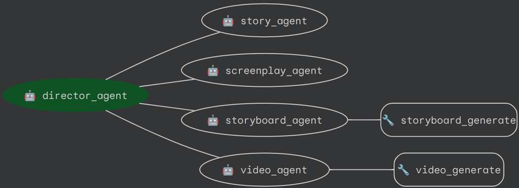

> Credit: https://github.com/google/adk-samples/tree/main/python/agents/short-movie-agents

# 🤔 Local vs Proprietary LLMs

# 🗣️ Voice Agents

uvicorn main:app --host 0.0.0.0 --port 8000 > server.log 2>&1 &

# References

- Welcome to Agno - Agno - https://docs.agno.com
- Building Effective AI Agents - https://www.anthropic.com/engineering/building-effective-agents
- Hybrid Search with Multiple Embeddings - Elasticsearch Labs - https://www.elastic.co/search-labs/blog/hybrid-search-multiple-embeddings
- What is RAG? - Retrieval-Augmented Generation AI Explained - AWS - https://aws.amazon.com/what-is/retrieval-augmented-generation

# Tools Used:

- Agno - https://docs.agno.com
- Llama - https://llama.com
- Ollama - https://ollama.com
- Mem0 - https://mem0.ai
- MCP Servers - https://github.com/modelcontextprotocol/servers

# Further Reading

- Aligning Language Models to Follow Instructions - https://openai.com/index/instruction-following/
- Training Language Models to Follow Instructions with Human Feedback - https://arxiv.org/abs/2203.02155
- Chain-of-Thought Prompting Elicits Reasoning in Large Language Models - https://arxiv.org/abs/2201.11903
- What is the Model Context Protocol (MCP)? - https://modelcontextprotocol.io/docs/getting-started/intro